# My visual data story

## Observing Phone Usage on the Train from Britomart to Papakura

For this project, I collaborated with my friend Wei and my flatmate Manson to collect observational data on how people use their phones while commuting. We travelled together on the Auckland train line from Britomart Station to Papakura Station, which allowed us to observe a wide range of passengers across different age groups.

## Average Duration by Activity

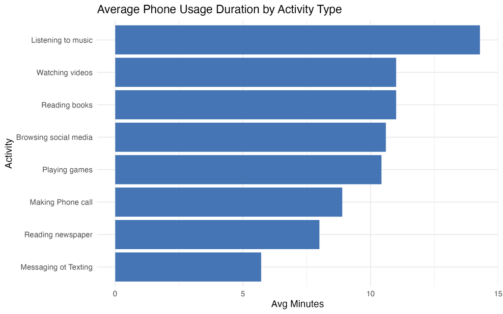

## Audible vs Silent Use Across Activities

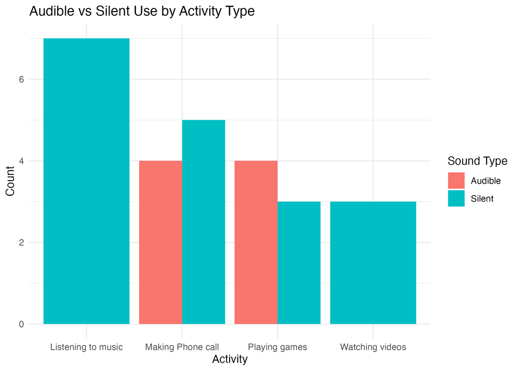

Audible usage

In this plot, we focus on activities that are more likely to involve sound — such as listening to music, watching videos, playing games, or making phone calls.

We can clearly see that: - **Music** and **videos** are always silent, with passengers using headphones. - **Games** and **Phone calls** had a mix of silent and audible use.

## What Time Were Observations Made?

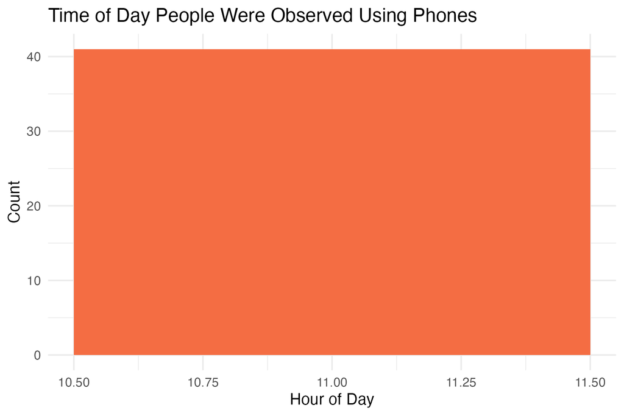

Observation time

Using the timestamp recorded in our Google Form, we visualised the distribution of observation times by hour.

## Conclusion

This observational project helped us better understand mobile phone habits in a public setting. By visualising the data, we noticed clear patterns in how people interact with their devices depending on the activity, noise level, and length of use. If extended, the project could include more time intervals, different train lines, or comparisons across weekdays vs weekends to gain deeper insights.